# STAT4340-Project1

2026-03-09

# Project 1 - Sanjit Subhash

## Phase 1

```r
library(tidyverse)
men <- read.csv("/Users/sanjitsubhash/Downloads/trainingData.csv")
women <- read.csv("/Users/sanjitsubhash/Downloads/trainingDataWomen.csv")

dim(men)
```

```
## [1] 1449   40
```

```r
dim(women)
```

```
## [1] 961  40
```

```r
names(men)
```

```
##  [1] "Season"     "DayNum"     "gameid"     "TeamName_A" "TeamName_B"
##  [6] "TeamID_A"   "TeamID_B"   "Win"        "Score_A"    "Score_B"
## [11] "FGM_A"      "FGM_B"      "FGA_A"      "FGA_B"      "FGM3_A"
## [16] "FGM3_B"     "FGA3_A"     "FGA3_B"     "FTM_A"      "FTM_B"
## [21] "FTA_A"      "FTA_B"      "OR_A"       "OR_B"       "DR_A"
## [26] "DR_B"       "Ast_A"      "Ast_B"      "TO_A"       "TO_B"
## [31] "Stl_A"      "Stl_B"      "Blk_A"      "Blk_B"      "PF_A"
## [36] "PF_B"       "Region_A"   "Seed_A"     "Region_B"   "Seed_B"
```

```r
head(men, 3)
```

```
##   Season DayNum gameid    TeamName_A  TeamName_B TeamID_A TeamID_B Win  Score_A
## 1   2003    134      1 UNC Asheville TX Southern     1421     1411   A 71.20690
## 2   2003    136      2       Arizona     Vermont     1112     1436   A 85.21429
## 3   2003    136      3       Memphis  Arizona St     1272     1113   B 74.51724
##    Score_B    FGM_A    FGM_B    FGA_A    FGA_B   FGM3_A   FGM3_B   FGA3_A
## 1 72.80000 24.37931 24.73333 56.79310 55.26667 6.482759 5.933333 18.00000
## 2 67.79310 30.32143 24.82759 65.71429 55.86207 7.035714 5.275862 20.07143
## 3 75.96552 26.27586 27.20690 60.00000 56.89655 7.000000 4.000000 20.06897
##     FGA3_B    FTM_A    FTM_B    FTA_A    FTA_B     OR_A     OR_B     DR_A
## 1 18.50000 15.96552 17.40000 20.93103 28.06667 12.27586 13.16667 23.17241
## 2 15.48276 17.53571 12.86207 25.00000 19.55172 15.17857 12.96552 27.64286
## 3 12.58621 14.96552 17.55172 22.89655 26.20690 14.06897 13.68966 25.96552
##       DR_B    Ast_A    Ast_B     TO_A     TO_B    Stl_A    Stl_B    Blk_A
## 1 24.80000 13.03448 14.20000 16.20690 15.23333 7.068966 6.433333 3.000000
## 2 25.72414 17.64286 14.20690 14.78571 14.06897 8.464286 6.862069 4.214286
## 3 23.31034 16.62069 15.55172 13.79310 14.00000 7.379310 5.206897 5.068966
##      Blk_B     PF_A     PF_B Region_A Seed_A Region_B Seed_B
## 1 2.233333 19.10345 18.30000        X     16        X     16
## 2 2.965517 17.75000 15.89655        Z      1        Z     16
## 3 4.241379 18.75862 19.41379        Z      7        Z     10
```

```r
head(women, 3)
```

```
##   Season DayNum gameid TeamName_A TeamName_B TeamID_A TeamID_B Win  Score_A
## 1   2010    138      1     Baylor  Fresno St     3124     3201   A 72.09375
## 2   2010    138      2     Dayton        TCU     3173     3395   A 70.76923
## 3   2010    138      3    Hampton       Duke     3214     3181   B 62.83333
##    Score_B    FGM_A    FGM_B    FGA_A    FGA_B   FGM3_A   FGM3_B   FGA3_A
## 1 73.45455 26.09375 25.84848 56.34375 61.57576 2.468750 8.818182  8.65625
## 2 72.30000 25.88462 25.83333 61.53846 62.26667 5.461538 6.866667 17.46154
## 3 71.59375 22.20000 26.84375 60.10000 63.75000 4.900000 4.562500 16.10000
##     FGA3_B    FTM_A    FTM_B    FTA_A    FTA_B     OR_A     OR_B     DR_A
## 1 24.84848 17.43750 12.93939 24.00000 18.24242 12.18750 13.87879 31.06250
## 2 19.20000 13.53846 13.76667 19.34615 18.40000 14.73077 13.50000 28.07692
## 3 14.46875 13.53333 13.34375 18.93333 20.15625 14.96667 17.71875 22.66667
##       DR_B    Ast_A    Ast_B     TO_A     TO_B     Stl_A     Stl_B    Blk_A
## 1 24.57576 14.68750 14.63636 16.87500 15.63636  6.968750 10.393939 7.250000
## 2 25.83333 14.46154 15.60000 16.96154 16.03333  7.730769  9.833333 4.076923
## 3 25.59375 11.60000 14.25000 15.53333 17.90625 10.100000 13.375000 2.233333
##      Blk_B     PF_A     PF_B Region_A Seed_A Region_B Seed_B
## 1 2.606061 14.12500 16.39394        X      4        X     13
## 2 3.600000 16.57692 16.23333        X      8        X      9
## 3 5.281250 18.83333 17.68750        X     15        X      2
```

```r
table(men$Win)
```

```
##
##   A   B
## 727 722
```

```r
table(women$Win)
```

```
##
##   A   B
## 486 475
```

The men’s dataset had 1449 observations and the women’s dataset had 961 observations. I also checked the response variable Win and found that the classes were very balanced in both datasets, which is helpful for classification modeling.

## Phase 2:

```r
men2 <- men %>%
  mutate(
    y = ifelse(Win == "A", 1, 0),
    SeedDiff = Seed_B - Seed_A,
    ScoreDiff = Score_A - Score_B,
    FGMDiff = FGM_A - FGM_B,
    FGADiff = FGA_A - FGA_B,
    FGM3Diff = FGM3_A - FGM3_B,
    FGA3Diff = FGA3_A - FGA3_B,
    FTMDiff = FTM_A - FTM_B,
    FTADiff = FTA_A - FTA_B,
    ORDiff = OR_A - OR_B,
    DRDiff = DR_A - DR_B,
    AstDiff = Ast_A - Ast_B,
    TODiff = TO_A - TO_B,
    StlDiff = Stl_A - Stl_B,
    BlkDiff = Blk_A - Blk_B,
    PFDiff = PF_A - PF_B
  ) %>%
  select(
    y, SeedDiff, ScoreDiff, FGMDiff, FGADiff, FGM3Diff, FGA3Diff,
    FTMDiff, FTADiff, ORDiff, DRDiff, AstDiff, TODiff,
    StlDiff, BlkDiff, PFDiff
  )

women2 <- women %>%
  mutate(
    y = ifelse(Win == "A", 1, 0),
    SeedDiff = Seed_B - Seed_A,
    ScoreDiff = Score_A - Score_B,
    FGMDiff = FGM_A - FGM_B,
    FGADiff = FGA_A - FGA_B,
    FGM3Diff = FGM3_A - FGM3_B,
    FGA3Diff = FGA3_A - FGA3_B,
    FTMDiff = FTM_A - FTM_B,
    FTADiff = FTA_A - FTA_B,
    ORDiff = OR_A - OR_B,
    DRDiff = DR_A - DR_B,
    AstDiff = Ast_A - Ast_B,
    TODiff = TO_A - TO_B,
    StlDiff = Stl_A - Stl_B,
    BlkDiff = Blk_A - Blk_B,
    PFDiff = PF_A - PF_B
  ) %>%
  select(
    y, SeedDiff, ScoreDiff, FGMDiff, FGADiff, FGM3Diff, FGA3Diff,
    FTMDiff, FTADiff, ORDiff, DRDiff, AstDiff, TODiff,
    StlDiff, BlkDiff, PFDiff
  )

head(men2, 3)
```

```
##   y SeedDiff ScoreDiff    FGMDiff  FGADiff  FGM3Diff  FGA3Diff   FTMDiff
## 1 1        0 -1.593103 -0.3540230 1.526437 0.5494253 -0.500000 -1.434483
## 2 1       15 17.421182  5.4938424 9.852217 1.7598522  4.588670  4.673645
## 3 0        3 -1.448276 -0.9310345 3.103448 3.0000000  7.482759 -2.586207
##     FTADiff     ORDiff    DRDiff   AstDiff     TODiff   StlDiff   BlkDiff
## 1 -7.135632 -0.8908046 -1.627586 -1.165517  0.9735632 0.6356322 0.7666667
## 2  5.448276  2.2130542  1.918719  3.435961  0.7167488 1.6022167 1.2487685
## 3 -3.310345  0.3793103  2.655172  1.068966 -0.2068966 2.1724138 0.8275862
##       PFDiff
## 1  0.8034483
## 2  1.8534483
## 3 -0.6551724
```

```r
head(women2, 3)
```

```
##   y SeedDiff ScoreDiff     FGMDiff    FGADiff  FGM3Diff   FGA3Diff    FTMDiff
## 1 1        9 -1.360795  0.24526515 -5.2320076 -6.349432 -16.192235  4.4981061
## 2 1        1 -1.530769  0.05128205 -0.7282051 -1.405128  -1.738462 -0.2282051
## 3 0      -13 -8.760417 -4.64375000 -3.6500000  0.337500   1.631250  0.1895833
##      FTADiff    ORDiff    DRDiff     AstDiff     TODiff   StlDiff    BlkDiff
## 1  5.7575758 -1.691288  6.486742  0.05113636  1.2386364 -3.425189  4.6439394
## 2  0.9461538  1.230769  2.243590 -1.13846154  0.9282051 -2.102564  0.4769231
## 3 -1.2229167 -2.752083 -2.927083 -2.65000000 -2.3729167 -3.275000 -3.0479167
##       PFDiff
## 1 -2.2689394
## 2  0.3435897
## 3  1.1458333
```

```r
summary(men2)
```

```
##        y             SeedDiff           ScoreDiff            FGMDiff
##  Min.   :0.0000   Min.   :-15.00000   Min.   :-22.89286   Min.   :-9.357143
##  1st Qu.:0.0000   1st Qu.: -5.00000   1st Qu.: -4.86720   1st Qu.:-1.992943
##  Median :1.0000   Median :  0.00000   Median :  0.12903   Median :-0.057576
##  Mean   :0.5017   Mean   :  0.05383   Mean   :  0.02173   Mean   : 0.004749
##  3rd Qu.:1.0000   3rd Qu.:  6.00000   3rd Qu.:  4.71385   3rd Qu.: 1.965726
##  Max.   :1.0000   Max.   : 15.00000   Max.   : 21.17380   Max.   : 8.677656
##     FGADiff             FGM3Diff            FGA3Diff
##  Min.   :-22.07143   Min.   :-5.246323   Min.   :-12.42789
##  1st Qu.: -3.14576   1st Qu.:-1.220919   1st Qu.: -2.80370
##  Median :  0.03030   Median : 0.031250   Median :  0.11029
##  Mean   : -0.07655   Mean   : 0.004629   Mean   : -0.02359
##  3rd Qu.:  3.02763   3rd Qu.: 1.201299   3rd Qu.:  2.75000
##  Max.   : 14.03676   Max.   : 6.062500   Max.   : 14.27849
##     FTMDiff              FTADiff              ORDiff             DRDiff
##  Min.   :-10.205882   Min.   :-13.09412   Min.   :-9.21429   Min.   :-9.28571
##  1st Qu.: -1.819853   1st Qu.: -2.26916   1st Qu.:-1.62745   1st Qu.:-1.60478
##  Median :  0.011029   Median : -0.02723   Median : 0.03125   Median : 0.06262
##  Mean   :  0.007607   Mean   :  0.02712   Mean   : 0.02701   Mean   : 0.08905
##  3rd Qu.:  1.857143   3rd Qu.:  2.49496   3rd Qu.: 1.72371   3rd Qu.: 1.76723
##  Max.   :  8.059629   Max.   : 10.82759   Max.   : 7.69223   Max.   : 9.01078
##     AstDiff             TODiff            StlDiff            BlkDiff
##  Min.   :-9.23265   Min.   :-7.58065   Min.   :-5.70370   Min.   :-6.24242
##  1st Qu.:-1.71836   1st Qu.:-1.23529   1st Qu.:-1.34375   1st Qu.:-1.12745
##  Median : 0.04963   Median : 0.06345   Median :-0.07116   Median : 0.02941
##  Mean   : 0.04597   Mean   : 0.10452   Mean   :-0.05219   Mean   : 0.02680
##  3rd Qu.: 1.86364   3rd Qu.: 1.44497   3rd Qu.: 1.19556   3rd Qu.: 1.10511
##  Max.   : 9.22014   Max.   : 7.66667   Max.   : 6.28368   Max.   : 6.75269
##      PFDiff
##  Min.   :-7.66488
##  1st Qu.:-1.73939
##  Median : 0.02941
##  Mean   : 0.02083
##  3rd Qu.: 1.73529
##  Max.   : 7.89655
```

```r
summary(women2)
```

```
##        y             SeedDiff           ScoreDiff           FGMDiff
##  Min.   :0.0000   Min.   :-15.00000   Min.   :-30.8485   Min.   :-13.84848
##  1st Qu.:0.0000   1st Qu.: -5.00000   1st Qu.: -6.1251   1st Qu.: -2.38310
##  Median :1.0000   Median :  0.00000   Median :  0.6172   Median :  0.05128
##  Mean   :0.5057   Mean   : -0.02289   Mean   :  0.1315   Mean   :  0.03579
##  3rd Qu.:1.0000   3rd Qu.:  5.00000   3rd Qu.:  6.3333   3rd Qu.:  2.65806
##  Max.   :1.0000   Max.   : 15.00000   Max.   : 27.0235   Max.   : 12.08016
##     FGADiff             FGM3Diff          FGA3Diff           FTMDiff
##  Min.   :-14.63352   Min.   :-7.6061   Min.   :-22.3448   Min.   :-8.58807
##  1st Qu.: -3.49539   1st Qu.:-1.3812   1st Qu.: -3.5991   1st Qu.:-2.03629
##  Median : -0.15152   Median : 0.1241   Median :  0.3317   Median : 0.00000
##  Mean   :  0.01606   Mean   : 0.1084   Mean   :  0.2670   Mean   :-0.04855
##  3rd Qu.:  3.45636   3rd Qu.: 1.6129   3rd Qu.:  4.2333   3rd Qu.: 1.82964
##  Max.   : 17.60000   Max.   : 7.0606   Max.   : 19.9592   Max.   : 8.10968
##     FTADiff              ORDiff             DRDiff
##  Min.   :-12.00473   Min.   :-8.56250   Min.   :-11.595833
##  1st Qu.: -2.71075   1st Qu.:-1.99091   1st Qu.: -2.329255
##  Median : -0.03125   Median : 0.05767   Median :  0.008065
##  Mean   : -0.04199   Mean   : 0.05701   Mean   :  0.003471
##  3rd Qu.:  2.50379   3rd Qu.: 2.09677   3rd Qu.:  2.321691
##  Max.   : 11.09892   Max.   : 9.28476   Max.   : 10.250000
##     AstDiff              TODiff           StlDiff            BlkDiff
##  Min.   :-10.12853   Min.   :-7.9044   Min.   :-8.59892   Min.   :-6.90909
##  1st Qu.: -2.03664   1st Qu.:-1.5161   1st Qu.:-1.88609   1st Qu.:-1.15017
##  Median :  0.09879   Median : 0.1396   Median : 0.01287   Median : 0.04738
##  Mean   :  0.15347   Mean   : 0.1203   Mean   :-0.03608   Mean   : 0.04364
##  3rd Qu.:  2.50417   3rd Qu.: 1.7977   3rd Qu.: 1.74879   3rd Qu.: 1.29032
##  Max.   : 11.55882   Max.   : 8.4750   Max.   : 7.25181   Max.   : 5.68750
##      PFDiff
##  Min.   :-9.463947
##  1st Qu.:-1.796371
##  Median : 0.004735
##  Mean   : 0.043031
##  3rd Qu.: 1.903226
##  Max.   : 9.233871
```

I felt this was a cleaner way to represent the matchup, since the model then focuses on how Team A compares to Team B rather than treating the raw team labels separately.

## Phase 3

```r
table(men2$y)
```

```
##
##   0   1
## 722 727
```

```r
table(women2$y)
```

```
##
##   0   1
## 475 486
```

```r
summary(men2[, c("SeedDiff", "ScoreDiff", "AstDiff", "TODiff", "StlDiff")])
```

```
##     SeedDiff           ScoreDiff            AstDiff             TODiff
##  Min.   :-15.00000   Min.   :-22.89286   Min.   :-9.23265   Min.   :-7.58065
##  1st Qu.: -5.00000   1st Qu.: -4.86720   1st Qu.:-1.71836   1st Qu.:-1.23529
##  Median :  0.00000   Median :  0.12903   Median : 0.04963   Median : 0.06345
##  Mean   :  0.05383   Mean   :  0.02173   Mean   : 0.04597   Mean   : 0.10452
##  3rd Qu.:  6.00000   3rd Qu.:  4.71385   3rd Qu.: 1.86364   3rd Qu.: 1.44497
##  Max.   : 15.00000   Max.   : 21.17380   Max.   : 9.22014   Max.   : 7.66667
##     StlDiff
##  Min.   :-5.70370
##  1st Qu.:-1.34375
##  Median :-0.07116
##  Mean   :-0.05219
##  3rd Qu.: 1.19556
##  Max.   : 6.28368
```

```r
summary(women2[, c("SeedDiff", "ScoreDiff", "AstDiff", "TODiff", "StlDiff")])
```

```
##     SeedDiff           ScoreDiff           AstDiff              TODiff
##  Min.   :-15.00000   Min.   :-30.8485   Min.   :-10.12853   Min.   :-7.9044
##  1st Qu.: -5.00000   1st Qu.: -6.1251   1st Qu.: -2.03664   1st Qu.:-1.5161
##  Median :  0.00000   Median :  0.6172   Median :  0.09879   Median : 0.1396
##  Mean   : -0.02289   Mean   :  0.1315   Mean   :  0.15347   Mean   : 0.1203
##  3rd Qu.:  5.00000   3rd Qu.:  6.3333   3rd Qu.:  2.50417   3rd Qu.: 1.7977
##  Max.   : 15.00000   Max.   : 27.0235   Max.   : 11.55882   Max.   : 8.4750
##     StlDiff
##  Min.   :-8.59892
##  1st Qu.:-1.88609
##  Median : 0.01287
##  Mean   :-0.03608
##  3rd Qu.: 1.74879
##  Max.   : 7.25181
```

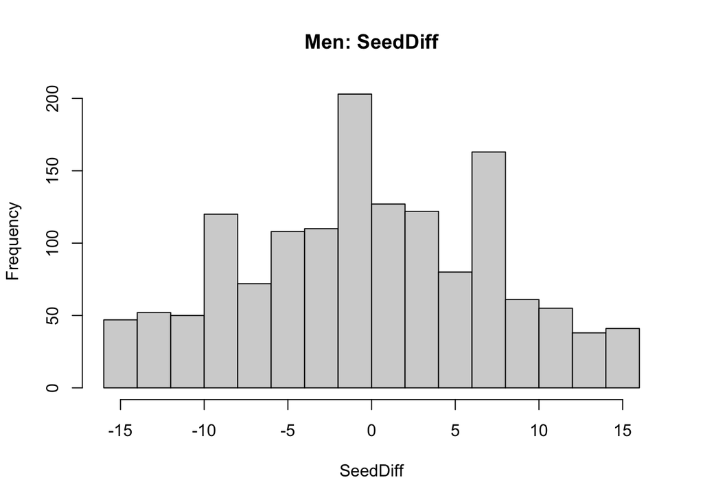

```r
hist(men2$SeedDiff, main = "Men: SeedDiff", xlab = "SeedDiff")
```

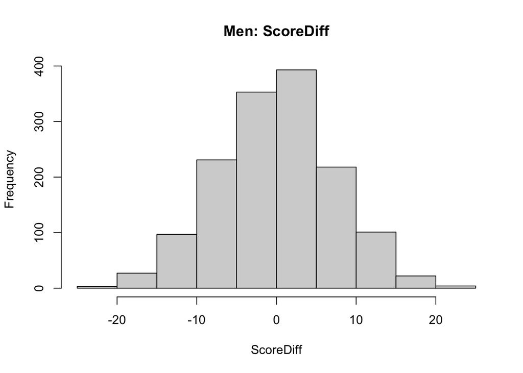

```r
hist(men2$ScoreDiff, main = "Men: ScoreDiff", xlab = "ScoreDiff")
```

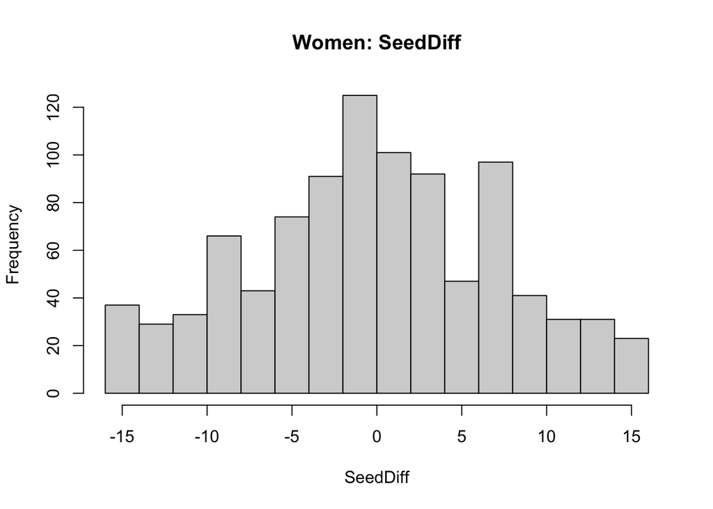

```r
hist(women2$SeedDiff, main = "Women: SeedDiff", xlab = "SeedDiff")
```

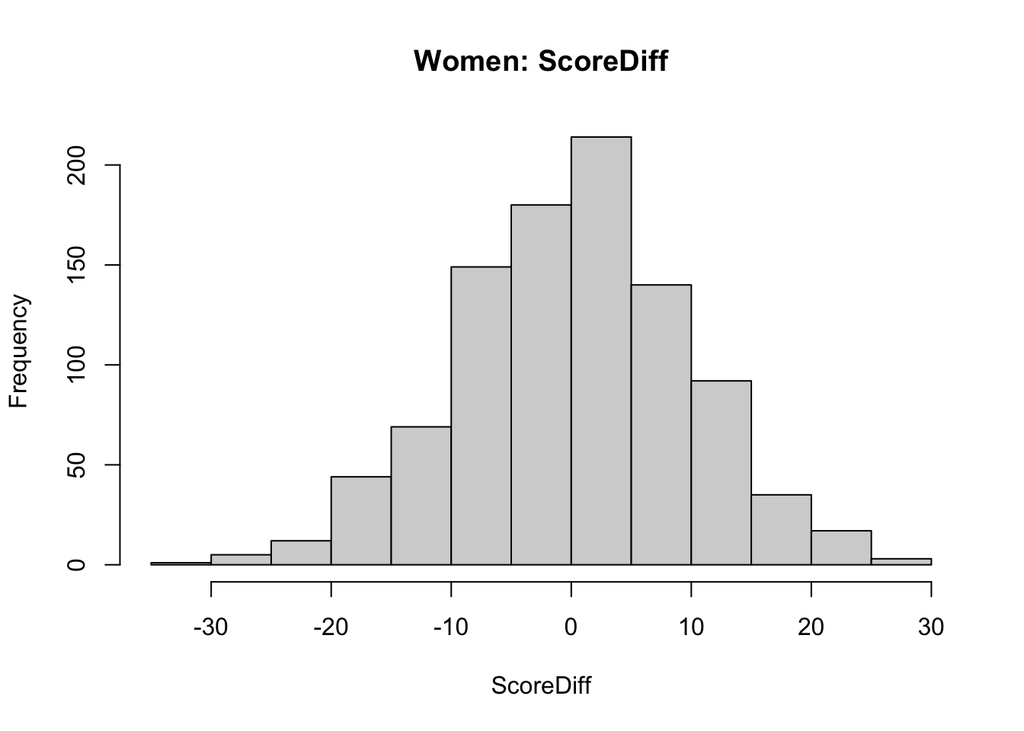

```r
hist(women2$ScoreDiff, main = "Women: ScoreDiff", xlab = "ScoreDiff")
```

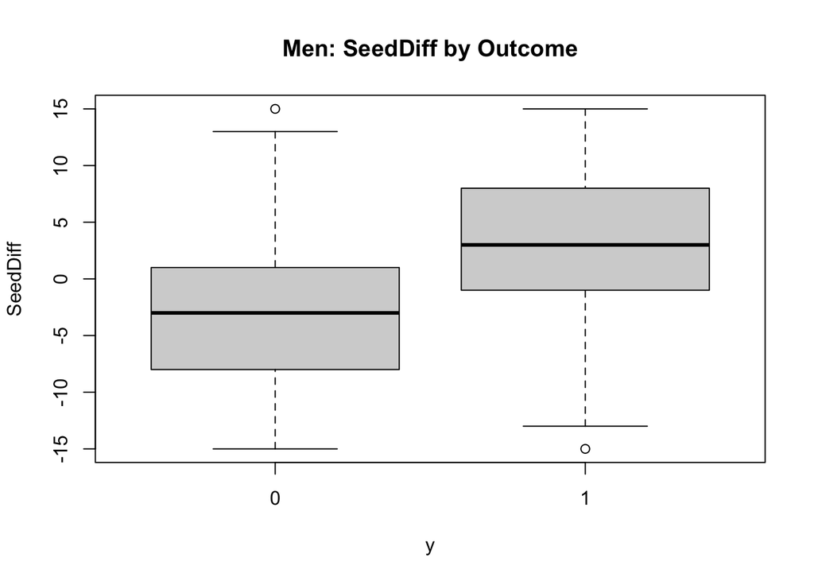

```r
boxplot(SeedDiff ~ y, data = men2, main = "Men: SeedDiff by Outcome")
```

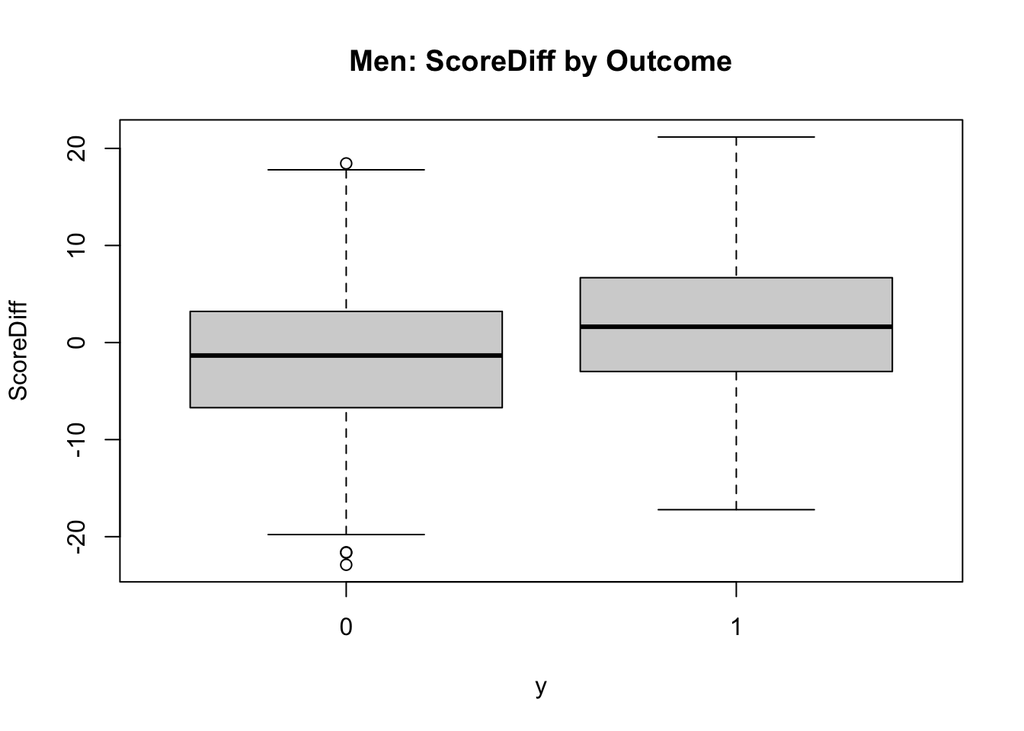

```r
boxplot(ScoreDiff ~ y, data = men2, main = "Men: ScoreDiff by Outcome")
```

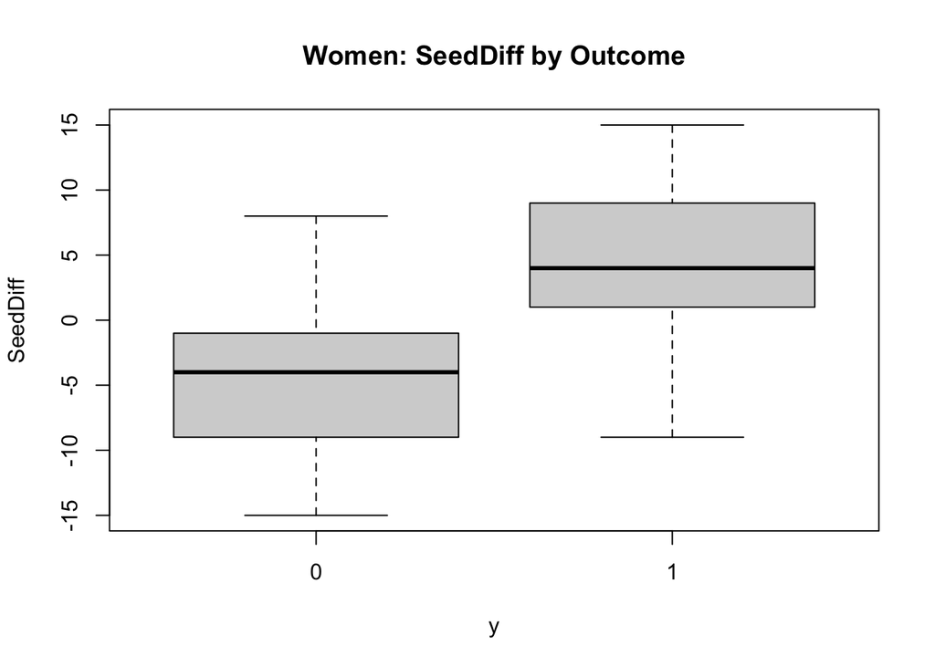

```r
boxplot(SeedDiff ~ y, data = women2, main = "Women: SeedDiff by Outcome")
```

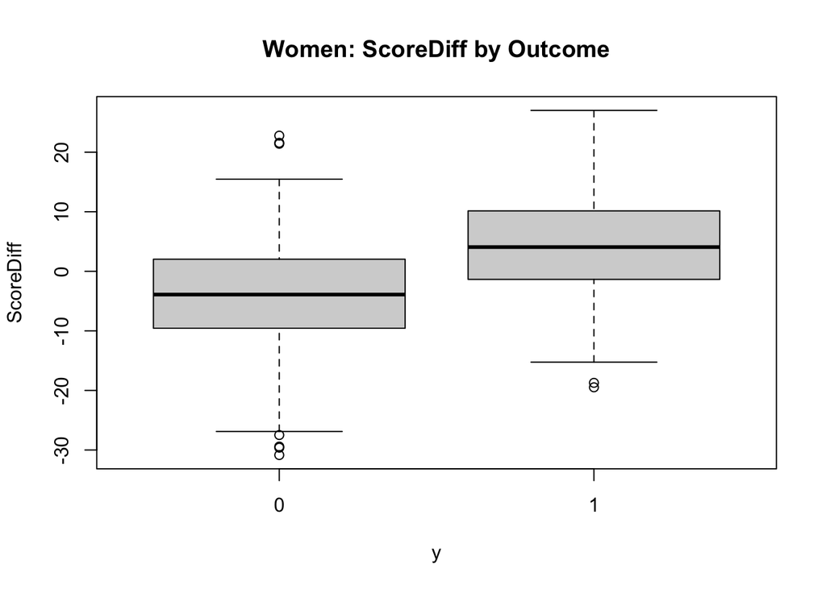

```r
boxplot(ScoreDiff ~ y, data = women2, main = "Women: ScoreDiff by Outcome")
```

```r
cor(men2[, -1])
```

```
##              SeedDiff  ScoreDiff     FGMDiff    FGADiff     FGM3Diff
## SeedDiff   1.00000000 0.42560543  0.43914683 0.29727890  0.112259736
## ScoreDiff  0.42560543 1.00000000  0.91730002 0.73163144  0.380215950
## FGMDiff    0.43914683 0.91730002  1.00000000 0.76801687  0.228931253
## FGADiff    0.29727890 0.73163144  0.76801687 1.00000000  0.204029350
## FGM3Diff   0.11225974 0.38021595  0.22893125 0.20402935  1.000000000
## FGA3Diff   0.04456056 0.26856861  0.11490714 0.25974601  0.916722832
## FTMDiff    0.13235474 0.47892610  0.17904117 0.19196493 -0.133669691
## FTADiff    0.10521787 0.42393633  0.17747625 0.24243293 -0.231765157
## ORDiff     0.27916215 0.33400164  0.34371858 0.65079615 -0.196771684
## DRDiff     0.31158070 0.49321373  0.49119219 0.35798248  0.016387869
## AstDiff    0.41093777 0.62642824  0.70032400 0.43100000  0.269979789
## TODiff    -0.22002531 0.07936108  0.03422588 0.04355232 -0.244160019
## StlDiff    0.09638991 0.25469173  0.27433495 0.42332314 -0.007417536
## BlkDiff    0.34693647 0.22983875  0.28800617 0.31699356 -0.167659552
## PFDiff    -0.22458132 0.08836000 -0.02393088 0.18702213 -0.045592883
##              FGA3Diff      FTMDiff     FTADiff     ORDiff      DRDiff
## SeedDiff   0.04456056  0.132354736  0.10521787  0.2791622  0.31158070
## ScoreDiff  0.26856861  0.478926103  0.42393633  0.3340016  0.49321373
## FGMDiff    0.11490714  0.179041166  0.17747625  0.3437186  0.49119219
## FGADiff    0.25974601  0.191964930  0.24243293  0.6507962  0.35798248
## FGM3Diff   0.91672283 -0.133669691 -0.23176516 -0.1967717  0.01638787
## FGA3Diff   1.00000000 -0.134847515 -0.19633315 -0.0878255 -0.03846454
## FTMDiff   -0.13484751  1.000000000  0.92039814  0.2966953  0.26761405
## FTADiff   -0.19633315  0.920398143  1.00000000  0.4453383  0.28799777
## ORDiff    -0.08782550  0.296695326  0.44533826  1.0000000  0.21460460
## DRDiff    -0.03846454  0.267614053  0.28799777  0.2146046  1.00000000
## AstDiff    0.15567996  0.008708073 -0.01476457  0.1611809  0.35585652
## TODiff    -0.20904225  0.304671846  0.40918720  0.2859576  0.20069499
## StlDiff    0.07121201  0.104399772  0.18361788  0.3087771 -0.21521742
## BlkDiff   -0.15381972  0.115201431  0.20205563  0.3870866  0.39489789
## PFDiff     0.02938549  0.320873394  0.38010767  0.2608214 -0.15394891
##                AstDiff      TODiff      StlDiff     BlkDiff      PFDiff
## SeedDiff   0.410937768 -0.22002531  0.096389912  0.34693647 -0.22458132
## ScoreDiff  0.626428235  0.07936108  0.254691725  0.22983875  0.08836000
## FGMDiff    0.700324004  0.03422588  0.274334953  0.28800617 -0.02393088
## FGADiff    0.431000004  0.04355232  0.423323138  0.31699356  0.18702213
## FGM3Diff   0.269979789 -0.24416002 -0.007417536 -0.16765955 -0.04559288
## FGA3Diff   0.155679955 -0.20904225  0.071212013 -0.15381972  0.02938549
## FTMDiff    0.008708073  0.30467185  0.104399772  0.11520143  0.32087339
## FTADiff   -0.014764575  0.40918720  0.183617884  0.20205563  0.38010767
## ORDiff     0.161180881  0.28595756  0.308777075  0.38708661  0.26082137
## DRDiff     0.355856522  0.20069499 -0.215217419  0.39489789 -0.15394891
## AstDiff    1.000000000  0.03675886  0.144302454  0.14897278 -0.10319356
## TODiff     0.036758857  1.00000000  0.213351917  0.15445062  0.41902034
## StlDiff    0.144302454  0.21335192  1.000000000  0.19906688  0.31388315
## BlkDiff    0.148972783  0.15445062  0.199066882  1.00000000 -0.05161742
## PFDiff    -0.103193563  0.41902034  0.313883152 -0.05161742  1.00000000
```

```r
cor(women2[, -1])
```

```
##              SeedDiff  ScoreDiff     FGMDiff     FGADiff    FGM3Diff
## SeedDiff   1.00000000  0.5989420  0.63112651  0.38129145 -0.07476998
## ScoreDiff  0.59894204  1.0000000  0.94803074  0.68604065  0.27885523
## FGMDiff    0.63112651  0.9480307  1.00000000  0.69877794  0.12691671
## FGADiff    0.38129145  0.6860406  0.69877794  1.00000000  0.10280711
## FGM3Diff  -0.07476998  0.2788552  0.12691671  0.10280711  1.00000000
## FGA3Diff  -0.20491970  0.1166556 -0.03934086  0.11652981  0.94102001
## FTMDiff    0.27727367  0.4311868  0.23237828  0.23041849 -0.25080621
## FTADiff    0.24392354  0.3151909  0.15726713  0.24882502 -0.37365894
## ORDiff     0.26344439  0.2361189  0.28125862  0.63597032 -0.34824048
## DRDiff     0.38874372  0.4679169  0.45589636  0.23654102  0.06248390
## AstDiff    0.43466803  0.7258824  0.77373897  0.37741393  0.25530726
## TODiff    -0.16514696 -0.2055118 -0.21620394 -0.06267482 -0.27580503
## StlDiff    0.05262131  0.2319789  0.26699423  0.41350187 -0.09767158
## BlkDiff    0.42639037  0.3119320  0.35633215  0.23490314 -0.14780580
## PFDiff    -0.24528098 -0.2134291 -0.26470760  0.16330475 -0.16404981
##              FGA3Diff     FTMDiff     FTADiff      ORDiff      DRDiff
## SeedDiff  -0.20491970  0.27727367  0.24392354  0.26344439  0.38874372
## ScoreDiff  0.11665558  0.43118677  0.31519094  0.23611895  0.46791692
## FGMDiff   -0.03934086  0.23237828  0.15726713  0.28125862  0.45589636
## FGADiff    0.11652981  0.23041849  0.24882502  0.63597032  0.23654102
## FGM3Diff   0.94102001 -0.25080621 -0.37365894 -0.34824048  0.06248390
## FGA3Diff   1.00000000 -0.27350409 -0.35735400 -0.27672008 -0.03398970
## FTMDiff   -0.27350409  1.00000000  0.92508896  0.28075477  0.22291155
## FTADiff   -0.35735400  0.92508896  1.00000000  0.43293021  0.17850201
## ORDiff    -0.27672008  0.28075477  0.43293021  1.00000000  0.07481850
## DRDiff    -0.03398970  0.22291155  0.17850201  0.07481850  1.00000000
## AstDiff    0.10409463  0.02354565 -0.08674876 -0.01483116  0.42123608
## TODiff    -0.20324644  0.15404919  0.25245270  0.24836810 -0.06943848
## StlDiff   -0.05757427  0.09971892  0.17024315  0.32842517 -0.39615611
## BlkDiff   -0.20203033  0.15545729  0.18821766  0.25800039  0.49612152
## PFDiff    -0.04677965  0.17368377  0.27496616  0.29627120 -0.40658862
##               AstDiff      TODiff       StlDiff       BlkDiff      PFDiff
## SeedDiff   0.43466803 -0.16514696  0.0526213061  0.4263903689 -0.24528098
## ScoreDiff  0.72588237 -0.20551176  0.2319788624  0.3119319756 -0.21342912
## FGMDiff    0.77373897 -0.21620394  0.2669942253  0.3563321540 -0.26470760
## FGADiff    0.37741393 -0.06267482  0.4135018662  0.2349031407  0.16330475
## FGM3Diff   0.25530726 -0.27580503 -0.0976715772 -0.1478058020 -0.16404981
## FGA3Diff   0.10409463 -0.20324644 -0.0575742671 -0.2020303301 -0.04677965
## FTMDiff    0.02354565  0.15404919  0.0997189226  0.1554572879  0.17368377
## FTADiff   -0.08674876  0.25245270  0.1702431510  0.1882176594  0.27496616
## ORDiff    -0.01483116  0.24836810  0.3284251681  0.2580003884  0.29627120
## DRDiff     0.42123608 -0.06943848 -0.3961561125  0.4961215223 -0.40658862
## AstDiff    1.00000000 -0.19099172  0.1615478171  0.2544283390 -0.35628875
## TODiff    -0.19099172  1.00000000  0.1985047005 -0.0570477595  0.50261676
## StlDiff    0.16154782  0.19850470  1.0000000000  0.0006167497  0.28592597
## BlkDiff    0.25442834 -0.05704776  0.0006167497  1.0000000000 -0.22827456
## PFDiff    -0.35628875  0.50261676  0.2859259745 -0.2282745647  1.00000000
```

## Phase 4: First baseline models

**(I) create factor response for caret/tree work**

```r
men2$y_factor <- factor(ifelse(men2$y == 1, "Awin", "Bwin"))
women2$y_factor <- factor(ifelse(women2$y == 1, "Awin", "Bwin"))

table(men2$y_factor)
```

```
##
## Awin Bwin
##  727  722
```

```r
table(women2$y_factor)
```

```
##
## Awin Bwin
##  486  475
```

**(II) Fit the first logistic regression**

```r
glm_men_small <- glm(
  y ~ SeedDiff + ScoreDiff + AstDiff + TODiff + StlDiff,
  data = men2,
  family = binomial
)

summary(glm_men_small)
```

```
##
## Call:
## glm(formula = y ~ SeedDiff + ScoreDiff + AstDiff + TODiff + StlDiff,
##     family = binomial, data = men2)
##
## Coefficients:
##               Estimate Std. Error z value Pr(>|z|)
## (Intercept)  0.0079566  0.0605172   0.131   0.8954
## SeedDiff     0.1501904  0.0106684  14.078   <2e-16 ***
## ScoreDiff    0.0134702  0.0112867   1.193   0.2327
## AstDiff      0.0007375  0.0300159   0.025   0.9804
## TODiff      -0.1001980  0.0319319  -3.138   0.0017 **
## StlDiff      0.0723238  0.0337262   2.144   0.0320 *
## ---
## Signif. codes:  0 '***' 0.001 '**' 0.01 '*' 0.05 '.' 0.1 ' ' 1
##
## (Dispersion parameter for binomial family taken to be 1)
##
##     Null deviance: 2008.7  on 1448  degrees of freedom
## Residual deviance: 1620.9  on 1443  degrees of freedom
## AIC: 1632.9
##
## Number of Fisher Scoring iterations: 4
```

**(III) Get predicted probabilities and classifications**

```r
men_probs_small <- predict(glm_men_small, type = "response")
men_pred_small <- ifelse(men_probs_small > 0.5, 1, 0)

table(Predicted = men_pred_small, Actual = men2$y)
```

```
##          Actual
## Predicted   0   1
##         0 505 212
##         1 217 515
```

```r
mean(men_pred_small == men2$y)
```

```
## [1] 0.7039337
```

**(IV) Fit the first classification tree**

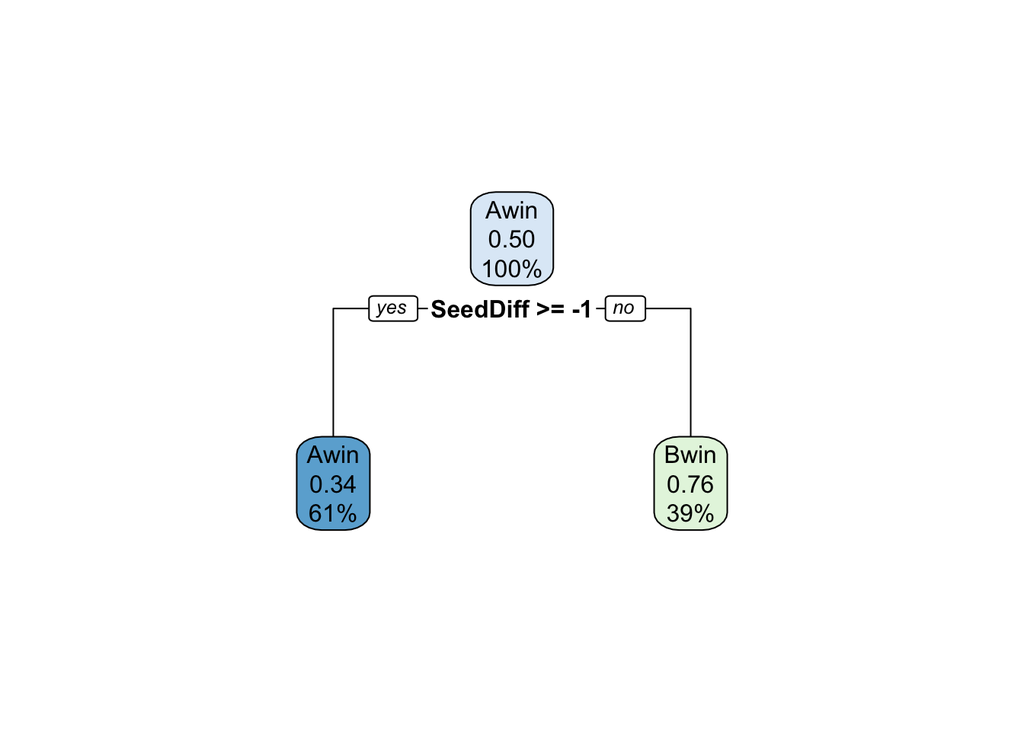

```r
library(rpart)
library(rpart.plot)
tree_men <- rpart(
  y_factor ~ SeedDiff + ScoreDiff + AstDiff + TODiff + StlDiff,
  data = men2,
  method = "class"
)

rpart.plot(tree_men)
```

```r
printcp(tree_men)
```

```
##
## Classification tree:
## rpart(formula = y_factor ~ SeedDiff + ScoreDiff + AstDiff + TODiff +
##     StlDiff, data = men2, method = "class")
##
## Variables actually used in tree construction:
## [1] SeedDiff
##
## Root node error: 722/1449 = 0.49827
##
## n= 1449
##
##        CP nsplit rel error  xerror     xstd
## 1 0.39751      0   1.00000 1.06233 0.026316
## 2 0.01000      1   0.60249 0.63158 0.024484
```

```r
tree_pred_class <- predict(tree_men, type = "class")
table(Predicted = tree_pred_class, Actual = men2$y_factor)
```

```
##          Actual
## Predicted Awin Bwin
##      Awin  591  299
##      Bwin  136  423
```

```r
mean(tree_pred_class == men2$y_factor)
```

```
## [1] 0.699793
```

# Phase 5: Expanded Model Comparison

**Men full logistic regression**

```r
glm_men_full <- glm(
  y ~ SeedDiff + ScoreDiff + FGMDiff + FGADiff + FGM3Diff + FGA3Diff +
    FTMDiff + FTADiff + ORDiff + DRDiff + AstDiff + TODiff +
    StlDiff + BlkDiff + PFDiff,
  data = men2,
  family = binomial
)

summary(glm_men_full)
```

```
##
## Call:
## glm(formula = y ~ SeedDiff + ScoreDiff + FGMDiff + FGADiff +
##     FGM3Diff + FGA3Diff + FTMDiff + FTADiff + ORDiff + DRDiff +
##     AstDiff + TODiff + StlDiff + BlkDiff + PFDiff, family = binomial,
##     data = men2)
##
## Coefficients: (1 not defined because of singularities)
##               Estimate Std. Error z value Pr(>|z|)
## (Intercept)  0.0005605  0.0612820   0.009 0.992703
## SeedDiff     0.1323680  0.0118844  11.138  < 2e-16 ***
## ScoreDiff    0.1381998  0.0650652   2.124 0.033668 *
## FGMDiff     -0.0524709  0.1386120  -0.379 0.705026
## FGADiff     -0.1345730  0.0391675  -3.436 0.000591 ***
## FGM3Diff    -0.1667246  0.1329176  -1.254 0.209717
## FGA3Diff     0.0304843  0.0463018   0.658 0.510292
## FTMDiff             NA         NA      NA       NA
## FTADiff     -0.1505474  0.0539337  -2.791 0.005249 **
## ORDiff       0.1832167  0.0486079   3.769 0.000164 ***
## DRDiff      -0.0043263  0.0379565  -0.114 0.909253
## AstDiff     -0.0622152  0.0356293  -1.746 0.080780 .
## TODiff      -0.1201954  0.0433097  -2.775 0.005516 **
## StlDiff      0.1076397  0.0460882   2.336 0.019516 *
## BlkDiff      0.0738346  0.0434483   1.699 0.089250 .
## PFDiff      -0.0215732  0.0323708  -0.666 0.505130
## ---
## Signif. codes:  0 '***' 0.001 '**' 0.01 '*' 0.05 '.' 0.1 ' ' 1
##
## (Dispersion parameter for binomial family taken to be 1)
##
##     Null deviance: 2008.7  on 1448  degrees of freedom
## Residual deviance: 1589.1  on 1434  degrees of freedom
## AIC: 1619.1
##
## Number of Fisher Scoring iterations: 4
```

**Men full logistic accuracy**

```r
men_probs_full <- predict(glm_men_full, type = "response")
men_pred_full <- ifelse(men_probs_full > 0.5, 1, 0)

table(Predicted = men_pred_full, Actual = men2$y)
```

```
##          Actual
## Predicted   0   1
##         0 511 204
##         1 211 523
```

```r
mean(men_pred_full == men2$y)
```

```
## [1] 0.7135956
```

**Women full logistic regression**

```r
glm_women_full <- glm(
  y ~ SeedDiff + ScoreDiff + FGMDiff + FGADiff + FGM3Diff + FGA3Diff +
    FTMDiff + FTADiff + ORDiff + DRDiff + AstDiff + TODiff +
    StlDiff + BlkDiff + PFDiff,
  data = women2,
  family = binomial
)

summary(glm_women_full)
```

```
##
## Call:
## glm(formula = y ~ SeedDiff + ScoreDiff + FGMDiff + FGADiff +
##     FGM3Diff + FGA3Diff + FTMDiff + FTADiff + ORDiff + DRDiff +
##     AstDiff + TODiff + StlDiff + BlkDiff + PFDiff, family = binomial,
##     data = women2)
##
## Coefficients: (1 not defined because of singularities)
##             Estimate Std. Error z value Pr(>|z|)
## (Intercept)  0.01330    0.08787   0.151  0.87966
## SeedDiff     0.23035    0.02039  11.298  < 2e-16 ***
## ScoreDiff    0.06781    0.09407   0.721  0.47104
## FGMDiff      0.05731    0.20311   0.282  0.77781
## FGADiff     -0.10776    0.04748  -2.269  0.02324 *
## FGM3Diff    -0.28391    0.19574  -1.450  0.14693
## FGA3Diff     0.06829    0.06290   1.086  0.27764
## FTMDiff           NA         NA      NA       NA
## FTADiff     -0.09169    0.07852  -1.168  0.24290
## ORDiff       0.09761    0.05605   1.741  0.08162 .
## DRDiff       0.01029    0.04724   0.218  0.82753
## AstDiff      0.03993    0.04627   0.863  0.38820
## TODiff      -0.11468    0.04935  -2.324  0.02014 *
## StlDiff      0.07180    0.05243   1.370  0.17082
## BlkDiff      0.17825    0.06214   2.869  0.00412 **
## PFDiff       0.02078    0.05009   0.415  0.67832
## ---
## Signif. codes:  0 '***' 0.001 '**' 0.01 '*' 0.05 '.' 0.1 ' ' 1
##
## (Dispersion parameter for binomial family taken to be 1)
##
##     Null deviance: 1332.10  on 960  degrees of freedom
## Residual deviance:  813.35  on 946  degrees of freedom
## AIC: 843.35
##
## Number of Fisher Scoring iterations: 5
```

**Women full logistic accuracy**

```r
women_probs_full <- predict(glm_women_full, type = "response")
women_pred_full <- ifelse(women_probs_full > 0.5, 1, 0)

table(Predicted = women_pred_full, Actual = women2$y)
```

```
##          Actual
## Predicted   0   1
##         0 373  96
##         1 102 390
```

```r
mean(women_pred_full == women2$y)
```

```
## [1] 0.7939646
```

**Random forest models**

```r
library(randomForest)
```

**Mens Random Forest**

```r
set.seed(123)

rf_men <- randomForest(
  as.factor(y) ~ SeedDiff + ScoreDiff + FGMDiff + FGADiff + FGM3Diff + FGA3Diff +
    FTMDiff + FTADiff + ORDiff + DRDiff + AstDiff + TODiff +
    StlDiff + BlkDiff + PFDiff,
  data = men2,
  importance = TRUE
)

rf_men
```

```
##
## Call:
##  randomForest(formula = as.factor(y) ~ SeedDiff + ScoreDiff +      FGMDiff + FGADiff + FGM3Diff + FGA3Diff + FTMDiff + FTADiff +      ORDiff + DRDiff + AstDiff + TODiff + StlDiff + BlkDiff +      PFDiff, data = men2, importance = TRUE)
##                Type of random forest: classification
##                      Number of trees: 500
## No. of variables tried at each split: 3
##
##         OOB estimate of  error rate: 31.4%
## Confusion matrix:
##     0   1 class.error
## 0 476 246   0.3407202
## 1 209 518   0.2874828
```

```r
importance(rf_men)
```

```
##                    0           1 MeanDecreaseAccuracy MeanDecreaseGini
## SeedDiff  41.2852538 45.18742565            57.107252        124.97770
## ScoreDiff  1.7480853  9.51993847             9.860470         41.56299
## FGMDiff    8.0656812  8.78374614            14.926680         49.66362
## FGADiff    1.5928769  3.78129080             4.600025         40.38793
## FGM3Diff  -1.4431661  4.79392318             2.839157         37.24774
## FGA3Diff  -0.2499719  2.01649297             1.345169         36.55343
## FTMDiff    5.5928166 -0.03532541             4.406830         36.83736
## FTADiff    6.4102962 -0.02377605             5.502319         37.53853
## ORDiff     6.4868700  3.89572638             7.798401         43.88336
## DRDiff     5.5296192 -1.71204150             2.863584         39.85686
## AstDiff    7.5776031  1.23484432             6.727043         48.51350
## TODiff     6.3615838  1.02760503             5.382577         48.08611
## StlDiff    1.7146825  6.43141195             5.969245         41.62731
## BlkDiff    6.9216687  5.15299645             8.509621         49.40513
## PFDiff     3.3767100  5.30595962             6.173509         47.85201
```

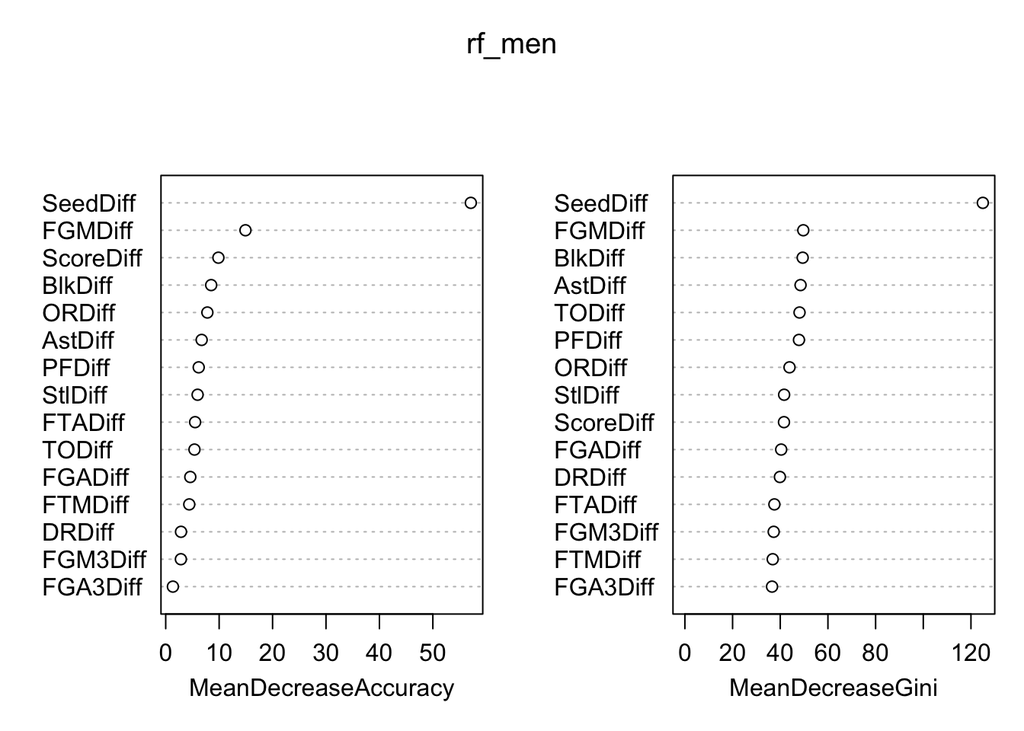

```r
varImpPlot(rf_men)
```

**Men random forest accuracy**

```r
rf_men_pred <- predict(rf_men, type = "class")
table(Predicted = rf_men_pred, Actual = as.factor(men2$y))
```

```
##          Actual
## Predicted   0   1
##         0 476 209
##         1 246 518
```

```r
mean(rf_men_pred == as.factor(men2$y))
```

```
## [1] 0.6859903
```

**Women Random Forest**

```r
set.seed(123)

rf_women <- randomForest(
  as.factor(y) ~ SeedDiff + ScoreDiff + FGMDiff + FGADiff + FGM3Diff + FGA3Diff +
    FTMDiff + FTADiff + ORDiff + DRDiff + AstDiff + TODiff +
    StlDiff + BlkDiff + PFDiff,
  data = women2,
  importance = TRUE
)

rf_women
```

```
##
## Call:
##  randomForest(formula = as.factor(y) ~ SeedDiff + ScoreDiff +      FGMDiff + FGADiff + FGM3Diff + FGA3Diff + FTMDiff + FTADiff +      ORDiff + DRDiff + AstDiff + TODiff + StlDiff + BlkDiff +      PFDiff, data = women2, importance = TRUE)
##                Type of random forest: classification
##                      Number of trees: 500
## No. of variables tried at each split: 3
##
##         OOB estimate of  error rate: 22.37%
## Confusion matrix:
##     0   1 class.error
## 0 366 109   0.2294737
## 1 106 380   0.2181070
```

```r
importance(rf_women)
```

```
##                    0         1 MeanDecreaseAccuracy MeanDecreaseGini
## SeedDiff  48.1075661 40.846270            58.195104        105.11287
## ScoreDiff 11.5050576 11.757168            19.089836         38.18407
## FGMDiff   18.7395397 16.301220            26.101180         52.80171
## FGADiff    7.9404341  5.969706            10.360180         25.52175
## FGM3Diff   0.4610224  3.320932             3.245659         20.17753
## FGA3Diff   3.8836384  2.915142             5.529084         22.30571
## FTMDiff    5.6484409  3.963384             7.210982         20.54273
## FTADiff    0.9895619  2.923055             2.840304         19.15038
## ORDiff     1.1311400  8.254347             7.451744         21.78634
## DRDiff    -1.4944488  8.197599             5.336499         23.83008
## AstDiff    7.6424249  8.829095            11.385165         29.54071
## TODiff     0.5198125  3.334464             2.730830         20.29813
## StlDiff    2.0318787  3.574365             4.099695         20.63175
## BlkDiff    4.2692640 10.765219            11.321314         34.93500
## PFDiff     4.8417755 11.519328            11.632581         25.08289
```

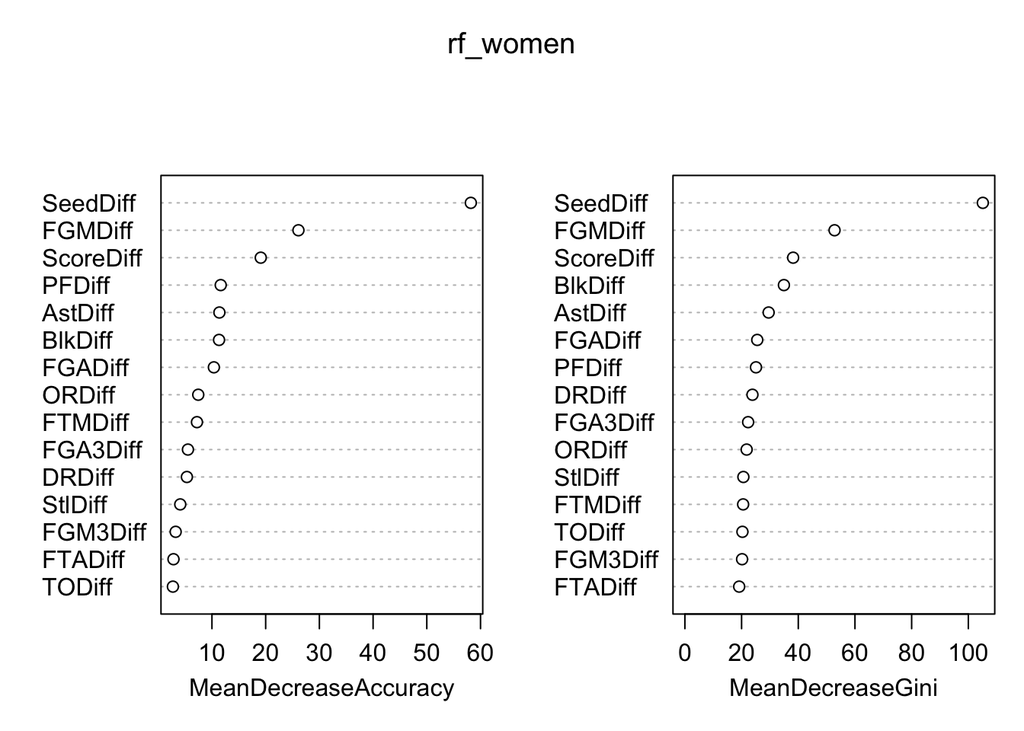

```r
varImpPlot(rf_women)
```

**Women random forest accuracy**

```r
rf_women_pred <- predict(rf_women, type = "class")
table(Predicted = rf_women_pred, Actual = as.factor(women2$y))
```

```
##          Actual
## Predicted   0   1
##         0 366 106
##         1 109 380
```

```r
mean(rf_women_pred == as.factor(women2$y))
```

```
## [1] 0.7762747
```

**Comparison table**

```r
glm_women_small <- glm(
  y ~ SeedDiff + ScoreDiff + AstDiff + TODiff + StlDiff,
  data = women2,
  family = binomial
)
```

```r
women_probs_small <- predict(glm_women_small, type = "response")
women_pred_small <- ifelse(women_probs_small > 0.5, 1, 0)
```

```r
tree_women <- rpart(
  y_factor ~ SeedDiff + ScoreDiff + AstDiff + TODiff + StlDiff,
  data = women2,
  method = "class"
)
```

```r
tree_women_pred <- predict(tree_women, type = "class")
```

```r
phase5_results <- data.frame(
  Model = c("Men Logistic Small", "Men Logistic Full", "Men Tree", "Men Random Forest",
            "Women Logistic Small", "Women Logistic Full", "Women Tree", "Women Random Forest"),
  Accuracy = c(
    mean(men_pred_small == men2$y),
    mean(men_pred_full == men2$y),
    mean(tree_pred_class == men2$y_factor),
    mean(rf_men_pred == as.factor(men2$y)),
    mean(women_pred_small == women2$y),
    mean(women_pred_full == women2$y),
    mean(tree_women_pred == women2$y_factor),
    mean(rf_women_pred == as.factor(women2$y))
  )
)

phase5_results
```

```
##                  Model  Accuracy
## 1   Men Logistic Small 0.7039337
## 2    Men Logistic Full 0.7135956
## 3             Men Tree 0.6997930
## 4    Men Random Forest 0.6859903
## 5 Women Logistic Small 0.7845994
## 6  Women Logistic Full 0.7939646
## 7           Women Tree 0.7804370
## 8  Women Random Forest 0.7762747
```

I wanted to see whether using more predictors would improve the model performance compared to the smaller baseline models from Phase 4, and I also wanted to compare logistic regression against a stronger tree-based method.

For the men’s data, the full logistic regression performed the best with an accuracy of about 71.4%, which was slightly better than the small logistic regression at about 70.4%. The men’s tree model had an accuracy of about 70.0%, while the men’s random forest was lower at about 68.6%. From this, I feel that logistic regression seems to be working better than the tree-based methods for the men’s dataset, at least based on the training accuracy I have so far.

For the women’s data, the full logistic regression again had the best performance, with an accuracy of about 79.4%. The small logistic regression was also strong at about 78.5%, and the women’s tree model was close behind at about 78.0%. The women’s random forest had an accuracy of about 77.6%. I think this suggests that the women’s models are performing a little better overall than the men’s models, and again the logistic regression seems to be the strongest option so far.

I think Phase 5 was useful because it showed that adding more predictors helped the logistic regression models a little, especially for both the men’s and women’s datasets. It also showed that even though random forest is a more flexible model, it did not outperform the logistic regression models here. At this point, the full logistic regression looks like the strongest model for both datasets, but I still want to confirm that with proper validation in the next phase instead of only relying on training accuracy.

# Phase 6

```r
library(caret)
library(rpart)
library(randomForest)
```

```r
men2$y_factor <- factor(ifelse(men2$y == 1, "Awin", "Bwin"))
women2$y_factor <- factor(ifelse(women2$y == 1, "Awin", "Bwin"))
```

```r
set.seed(123)

ctrl <- trainControl(
  method = "cv",
  number = 10,
  classProbs = TRUE,
  summaryFunction = twoClassSummary,
  savePredictions = "final"
)
```

```r
small_vars <- c("SeedDiff", "ScoreDiff", "AstDiff", "TODiff", "StlDiff")

full_vars <- c("SeedDiff", "ScoreDiff", "FGMDiff", "FGADiff", "FGM3Diff",
               "FGA3Diff", "FTMDiff", "FTADiff", "ORDiff", "DRDiff",
               "AstDiff", "TODiff", "StlDiff", "BlkDiff", "PFDiff")
```

```r
cv_glm_men_small <- train(
  x = men2[, small_vars],
  y = men2$y_factor,
  method = "glm",
  family = binomial,
  metric = "ROC",
  trControl = ctrl
)
```

```r
cv_glm_men_full <- train(
  x = men2[, full_vars],
  y = men2$y_factor,
  method = "glm",
  family = binomial,
  metric = "ROC",
  trControl = ctrl
)
```

```r
cv_tree_men <- train(
  x = men2[, full_vars],
  y = men2$y_factor,
  method = "rpart",
  metric = "ROC",
  trControl = ctrl,
  tuneLength = 10
)
```

```r
cv_rf_men <- train(
  x = men2[, full_vars],
  y = men2$y_factor,
  method = "rf",
  metric = "ROC",
  trControl = ctrl,
  tuneLength = 5
)
```

```r
cv_glm_women_small <- train(
  x = women2[, small_vars],
  y = women2$y_factor,
  method = "glm",
  family = binomial,
  metric = "ROC",
  trControl = ctrl
)
```

```r
cv_glm_women_full <- train(
  x = women2[, full_vars],
  y = women2$y_factor,
  method = "glm",
  family = binomial,
  metric = "ROC",
  trControl = ctrl
)
```

```r
cv_tree_women <- train(
  x = women2[, full_vars],
  y = women2$y_factor,
  method = "rpart",
  metric = "ROC",
  trControl = ctrl,
  tuneLength = 10
)
```

```r
cv_rf_women <- train(
  x = women2[, full_vars],
  y = women2$y_factor,
  method = "rf",
  metric = "ROC",
  trControl = ctrl,
  tuneLength = 5
)
```

```r
men_cv_results <- resamples(list(
  Logistic_Small = cv_glm_men_small,
  Logistic_Full = cv_glm_men_full,
  Tree = cv_tree_men,
  Random_Forest = cv_rf_men
))

summary(men_cv_results)
```

```
##
## Call:
## summary.resamples(object = men_cv_results)
##
## Models: Logistic_Small, Logistic_Full, Tree, Random_Forest
## Number of resamples: 10
##
## ROC
##                     Min.   1st Qu.    Median      Mean   3rd Qu.      Max. NA's
## Logistic_Small 0.7041476 0.7578006 0.7766623 0.7770798 0.8020358 0.8447145    0
## Logistic_Full  0.7500000 0.7596556 0.7702626 0.7819667 0.8097346 0.8247326    0
## Tree           0.6296679 0.6858893 0.7136863 0.7116569 0.7344817 0.7785388    0
## Random_Forest  0.6621956 0.7330541 0.7593898 0.7521883 0.7789907 0.7949460    0
##
## Sens
##                     Min.   1st Qu.    Median      Mean   3rd Qu.      Max. NA's
## Logistic_Small 0.6164384 0.6746575 0.7172755 0.7057458 0.7260274 0.8055556    0
## Logistic_Full  0.6250000 0.6712329 0.6965373 0.7095700 0.7397260 0.8356164    0
## Tree           0.5890411 0.6575342 0.7123288 0.7029871 0.7500000 0.7916667    0
## Random_Forest  0.5616438 0.6954909 0.7397260 0.7207953 0.7636986 0.7916667    0
##
## Spec
##                     Min.   1st Qu.    Median      Mean   3rd Qu.      Max. NA's
## Logistic_Small 0.6250000 0.6736111 0.6944444 0.7077435 0.7291667 0.8333333    0
## Logistic_Full  0.5138889 0.6944444 0.7152778 0.7021119 0.7388223 0.8055556    0
## Tree           0.5694444 0.5945586 0.6482116 0.6468798 0.6979167 0.7361111    0
## Random_Forest  0.5833333 0.6401256 0.6666667 0.6635464 0.6944444 0.7500000    0
```

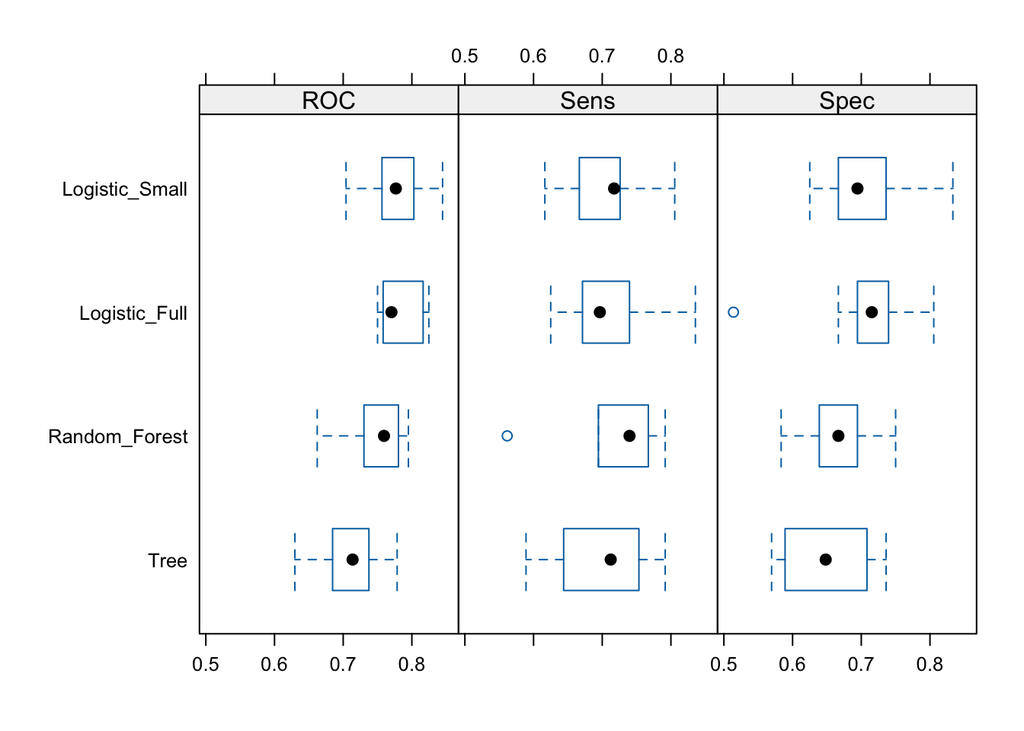

```r
bwplot(men_cv_results)
```

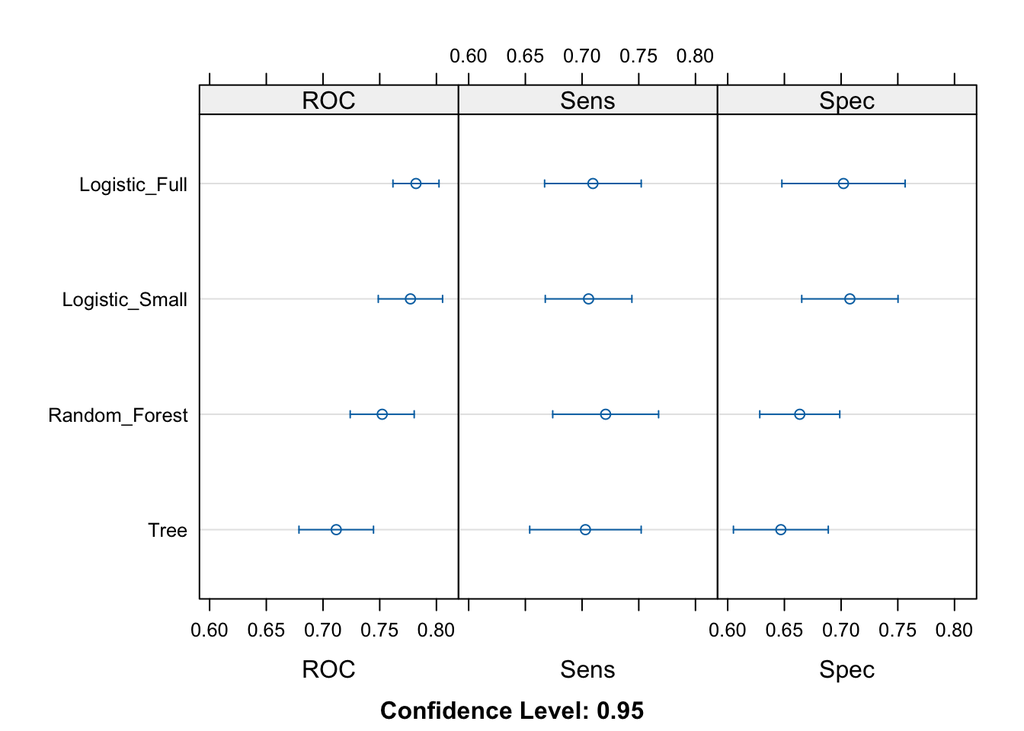

```r
dotplot(men_cv_results)
```

```r
women_cv_results <- resamples(list(
  Logistic_Small = cv_glm_women_small,
  Logistic_Full = cv_glm_women_full,
  Tree = cv_tree_women,
  Random_Forest = cv_rf_women
))

summary(women_cv_results)
```

```
##
## Call:
## summary.resamples(object = women_cv_results)
##
## Models: Logistic_Small, Logistic_Full, Tree, Random_Forest
## Number of resamples: 10
##
## ROC
##                     Min.   1st Qu.    Median      Mean   3rd Qu.      Max. NA's
## Logistic_Small 0.7444728 0.8594587 0.8878591 0.8713951 0.9014985 0.9140071    0
## Logistic_Full  0.7769097 0.8422710 0.8767130 0.8692877 0.8991623 0.9277482    0
## Tree           0.7551020 0.7965697 0.8160391 0.8186164 0.8298438 0.8791233    0
## Random_Forest  0.8014323 0.8386220 0.8568240 0.8570551 0.8750136 0.9071181    0
##
## Sens
##                     Min.   1st Qu.    Median      Mean   3rd Qu.      Max. NA's
## Logistic_Small 0.6938776 0.7385204 0.7838010 0.7759779 0.8153699 0.8541667    0
## Logistic_Full  0.6666667 0.7708333 0.7940051 0.7857568 0.8163265 0.8571429    0
## Tree           0.6250000 0.7135417 0.7551020 0.7426446 0.7755102 0.8333333    0
## Random_Forest  0.6734694 0.7193878 0.7731718 0.7698980 0.7755102 0.9166667    0
##
## Spec
##                     Min.   1st Qu.    Median      Mean   3rd Qu.      Max. NA's
## Logistic_Small 0.5625000 0.7343750 0.8297872 0.7834663 0.8510638 0.8750000    0
## Logistic_Full  0.5833333 0.7512190 0.8000887 0.7812057 0.8254654 0.8750000    0
## Tree           0.6808511 0.6911569 0.7471188 0.7452571 0.7831339 0.8297872    0
## Random_Forest  0.6875000 0.7248449 0.7473404 0.7495124 0.7831339 0.8085106    0
```

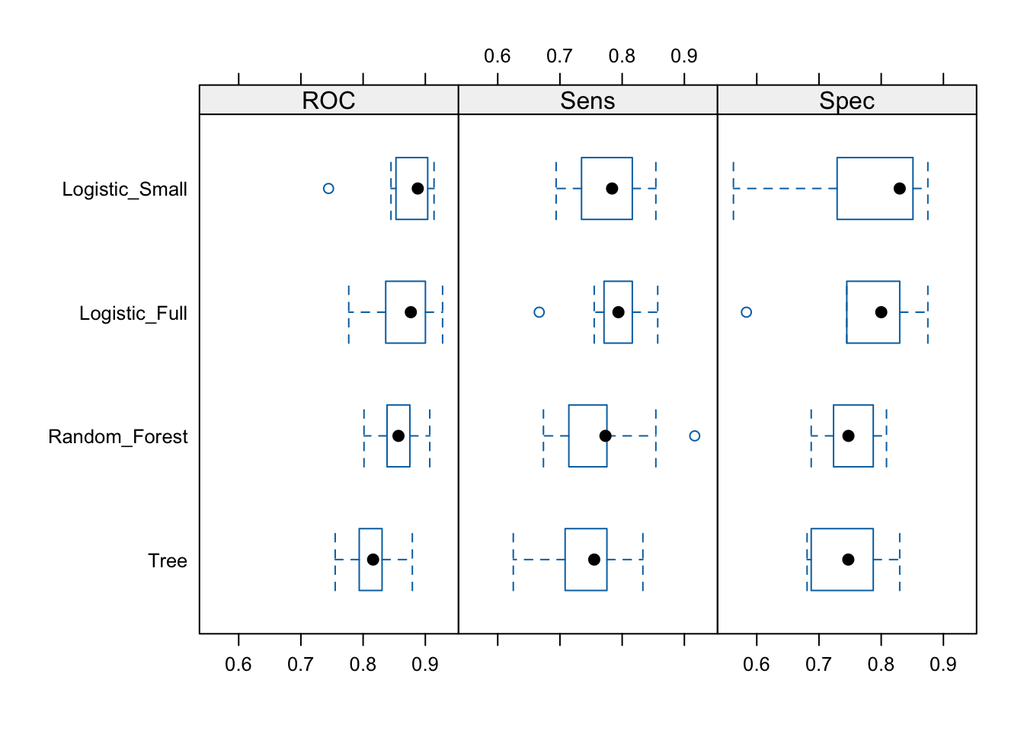

```r
bwplot(women_cv_results)
```

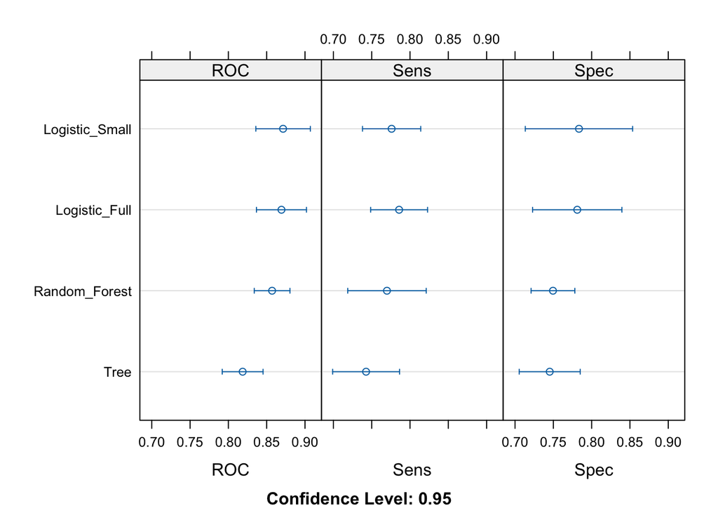

```r
dotplot(women_cv_results)
```

```r
men_phase6_table <- data.frame(
  Model = c("Men Logistic Small", "Men Logistic Full", "Men Tree", "Men Random Forest"),
  ROC = c(
    max(cv_glm_men_small$results$ROC),
    max(cv_glm_men_full$results$ROC),
    max(cv_tree_men$results$ROC),
    max(cv_rf_men$results$ROC)
  )
)

men_phase6_table
```

```
##                Model       ROC
## 1 Men Logistic Small 0.7770798
## 2  Men Logistic Full 0.7819667
## 3           Men Tree 0.7116569
## 4  Men Random Forest 0.7521883
```

```r
women_phase6_table <- data.frame(
  Model = c("Women Logistic Small", "Women Logistic Full", "Women Tree", "Women Random Forest"),
  ROC = c(
    max(cv_glm_women_small$results$ROC),
    max(cv_glm_women_full$results$ROC),
    max(cv_tree_women$results$ROC),
    max(cv_rf_women$results$ROC)
  )
)

women_phase6_table
```

```
##                  Model       ROC
## 1 Women Logistic Small 0.8713951
## 2  Women Logistic Full 0.8692877
## 3           Women Tree 0.8186164
## 4  Women Random Forest 0.8570551
```

I think this was more useful than only using training accuracy because it gives a better idea of how the models might perform on new tournament matchups.